# Response to Soil Type and Competition

December 2022

#Background We used a two-way factorial design with construction soil and natural soil and three competition treatments (*Dittrichia graveolens* grown alone, with *Bromus hordeaceus*, or with *Festuca perennis*). These grasses were selected because they are commonly found in California annual grasslands and were identified in many of the 8 paired sites. We collected *B. hordeaceus* seeds from Blue Oak Ranch Reserve and *F. perennis* seeds from the Terrace Lands of Younger Lagoon Reserve on the UCSC Coastal Science Campus.

Every pot had either one *D. graveolens* with one *B. hordeaceus* or one with *F. perennis*, or no grass competitor (grown alone). We prepared Deepots (D16; 5cm diameter, 18cm height) at the UCSC Coastal Science Campus Greenhouse and filled with rehydrated soil: 384 pots were filled with natural soil, and 384 with construction soil (768 pots total).

We germinated *D. graveolens* seeds in an incubation chamber with a daytime temperature of 23ºC from 9AM-1AM and a nighttime temperature of 19ºC from 1AM-9AM. Grasses were germinated in trays with potting mix and placed under fluorescent light banks for 16-hour length days and 8-hour length nights. Once radicles and cotyledons emerged, seedlings were transplanted in sets of six (one for each treatment) and then randomized into a blocked design.

After 4 months, we measured grass height from the soil surface to the longest tip of each grass bundle and measured *D. graveolens* leaf length from stem node to leaf tip of the longest newest true leaf to obtain an accurate estimate of the rosette size. We then harvested aboveground biomass at the crown and dried it in a 60ºC oven for 3 days before weighing it.

#Data Analysis Statistical analyses were performed in R version 4.2.1 (R Core Team 2022) using a two-way factorial ANOVA to test for the effects of soil and of competition on *D. graveolens* biomass. We used a post-hoc Tukey test to compare the three competitive treatments (grown alone, with *B. hordeaceus*, and with *F. perennis*) for each soil type separately. We also quantified the response of *D. graveolens* to the biomass of each competitor using linear regression models.

We tested for a difference between roadside and adjacent vegetation habitat types on each soil type independently, using mixed-model ANOVA, with site as a random effect and habitat (roadside or adjacent vegetation) as a fixed effect. Biomass of both *D. graveolens* and the grass competitors was ln-transformed before analysis.

#Libraries

```r
#install.packages("ggplot2")
#install.packages("tidyverse")
#install.packages("dplyr")
#install.packages("tidyr")
#install.packages("RColorBrewer")
#install.packages("data.table")
#install.packages("emmeans")
#install.packages("lme4")
#install.packages("patchwork")
#install.packages("Sleuth2")
library(ggplot2)
library(tidyverse)
library(dplyr)
library(tidyr)
library(RColorBrewer)
library(data.table)
library(emmeans)
library(lme4)
library(patchwork)
library(Sleuth2)
```

#Load Data This dataframe has one row per pot (768 observations). Data are Dittrichia_biomass and Grass_biomass, both measured in grams, and DittrichiaLLL_mm_3 which is the longest leaf length in mm. NAs in columns are “no data” because there was no grass present in that pot at the time of measurement.

```r
mydata<-read.csv("/Users/Miranda/Documents/Education/UC Santa Cruz/Dittrichia/Dittrichia_Analysis/data/greenhouse_competition/greenhouse_competition.csv",stringsAsFactors=T)
# change "NA" to "0"
mydata1<-mydata %>%
  replace_na(list(Dittrichia_biomass=0,Grass_biomass=0,DittrichiaLLL_mm_3=0,GrassHeight_cm_3=0))
str(mydata) #Check that each column has the right class (factor, integer, numeric, etc.)
```

```
'data.frame':   768 obs. of  18 variables:
 $ Pot.ID            : int  1 2 3 4 5 6 7 8 9 10 ...
 $ Block             : int  1 2 3 4 5 6 7 8 1 2 ...
 $ Soil              : Factor w/ 2 levels "Construction Soil",..: 1 1 1 1 1 1 1 1 1 1 ...
 $ Competition       : Factor w/ 3 levels "Bromus","Festuca",..: 3 3 3 3 3 3 3 3 3 3 ...
 $ Population        : Factor w/ 16 levels "BAY-R","BAY-V",..: 2 2 2 2 2 2 2 2 1 1 ...
 $ Site              : Factor w/ 8 levels "BAY","CHE","GUA",..: 1 1 1 1 1 1 1 1 1 1 ...
 $ Habitat           : Factor w/ 2 levels "Roadside","Vegetated": 2 2 2 2 2 2 2 2 1 1 ...
 $ Biomass_date      : Factor w/ 8 levels "12/10/22","12/11/22",..: 7 8 4 4 6 3 5 2 7 8 ...
 $ Dittrichia_biomass: num  0.0015 0.0021 0.0056 0.0073 0.0065 0.0034 0.0019 0.005 0.0033 0.002 ...
 $ Grass_biomass     : num  NA NA NA NA NA NA NA NA NA NA ...
 $ MeasurementDate_2 : Factor w/ 4 levels "9/14/21","9/15/21",..: 1 2 2 3 3 3 3 3 1 2 ...
 $ MeasurementDate_3 : Factor w/ 3 levels "10/15/21","10/16/21",..: 1 2 2 2 2 3 3 3 1 2 ...
 $ GrassHeight_cm_2  : num  NA NA NA NA NA NA NA NA NA NA ...
 $ GrassHeight_cm_3  : num  NA NA NA NA NA NA NA NA NA NA ...
 $ GrassGrowth       : num  0 0 0 0 0 0 0 0 0 0 ...
 $ DittrichiaLLL_mm_2: num  5.54 7.58 10.42 12.82 7.25 ...
 $ DittrichiaLLL_mm_3: num  5.67 6.09 13.34 11.59 8.63 ...
 $ DittrichiaGrowth  : num  0.13 -1.49 2.92 -1.23 1.38 -0.14 -5.21 -2.23 -1.2 -5.36 ...
```

#Dittrichia Biomass ##Histograms ###Original data The original data is skewed. So let’s try log-transforming.

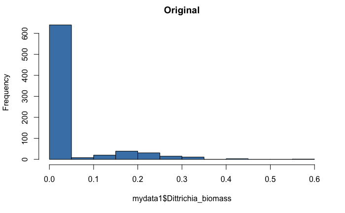

```r
#Dittrichia biomass
hist(mydata1$Dittrichia_biomass,col='steelblue',main='Original')
```

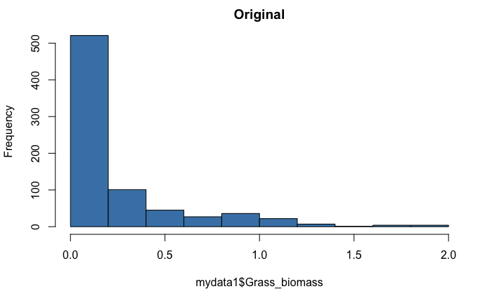

```r
#Grass biomass
hist(mydata1$Grass_biomass,col='steelblue',main='Original')
```

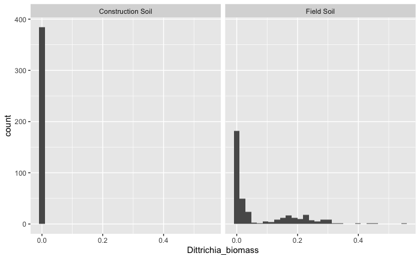

```r
#By soil type
ggplot(mydata1,aes(x=Dittrichia_biomass))+
  geom_histogram()+
  facet_wrap(vars(Soil))
```

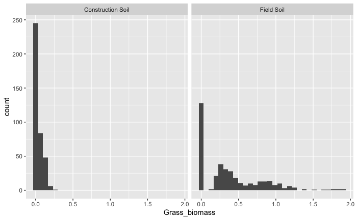

```r
ggplot(mydata1,aes(x=Grass_biomass))+
  geom_histogram()+
  facet_wrap(vars(Soil))
```

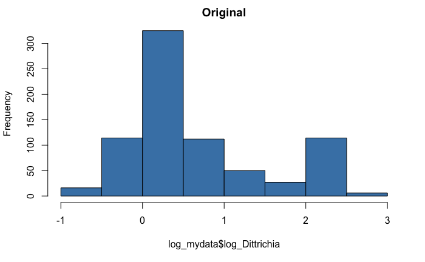

```r
#Prepare data for log transform (doing ln and log10)
log_mydata<-mydata1%>%
  mutate(Dittrichia_biomass1000=Dittrichia_biomass*1000,Grass_biomass1000=Grass_biomass*1000)%>%
  filter(Dittrichia_biomass!=0)%>%
  mutate(log_Dittrichia=log10(Dittrichia_biomass1000))%>%
  mutate(log_Grass=log10(Grass_biomass1000))%>%
  mutate(log_DittrichiaO=log10(Dittrichia_biomass))%>%
  mutate(log_GrassO=log10(Grass_biomass))

hist(log_mydata$log_Dittrichia,col='steelblue',main='Original')
```

```r
shapiro.test(log_mydata$log_Dittrichia) #does not improve with log transform
```

```
    Shapiro-Wilk normality test

data:  log_mydata$log_Dittrichia
W = 0.86154, p-value < 2.2e-16
```

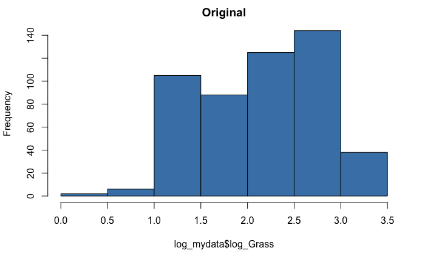

```r
hist(log_mydata$log_Grass,col='steelblue',main='Original')
```

```r
shapiro.test(log_mydata$log_Grass) #does not compute?
```

```
    Shapiro-Wilk normality test

data:  log_mydata$log_Grass
W = NaN, p-value = NA
```

##Model

###Best Model

###Risk Assessment

All data combined.

#####Biomass vs. Competition: Construction soil

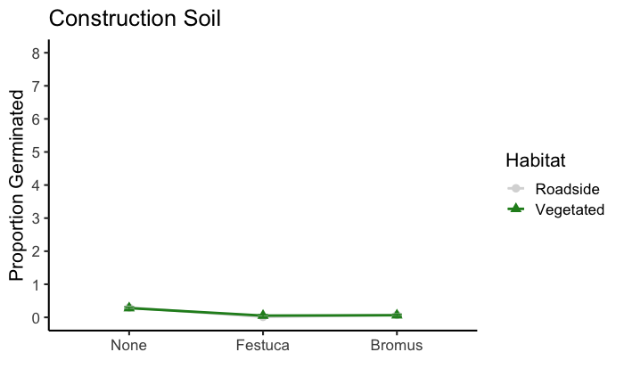

```r
pd<-position_dodge(0)

comp_int_bio_con<-log_mydata%>%
  filter(Soil=="Construction Soil") %>%
  group_by(Competition,Habitat)%>%
  summarise(Mean=mean(log_Dittrichia),
            SD=sd(log_Dittrichia),
            N=length(log_Dittrichia))%>%
  mutate(SE=SD/sqrt(N))
comp_int_bio_con_gg<-ggplot(data=comp_int_bio_con,
                        aes(x=factor(Competition,levels=c("None","Festuca","Bromus")),
                            y=Mean,
                            shape=Habitat,
                            group=Habitat,
                            color=Habitat))+
  ylab("log(Biomass)")+
  #coord_cartesian(ylim=c(1,8))+
  xlab("")+
  ggtitle("Construction Soil")+
  theme_classic(base_size=16)+
  scale_y_continuous(name="Proportion Germinated", #y-axis: title
                     limits=c(0,8), #x-axis: range
                     breaks=seq(0,8,1))+ #x-axis: incremental breaks by giving range and requesting a sequence by 1
  theme(panel.border=element_blank(),
        panel.grid.major=element_blank(),
        panel.grid.minor=element_blank(),
        axis.line=element_line(colour="black"))+
  geom_line(size=1,
            position=pd)+
  geom_point(size=3,
             position=pd)+
  scale_color_manual(values=c("gray85","forestgreen"))+
  geom_errorbar(width=0.15,
                position=pd,
                aes(ymin=(Mean-SE),
                    ymax=(Mean+SE)))
comp_int_bio_con_gg
```

```r
#ggsave(plot=comp_int_bio_con_gg,file="/Users/Miranda/Documents/Education/UC Santa Cruz/Dittrichia/Dittrichia_Analysis/figures/comp_int_bio_con_gg.png",width=25,height=20,units="cm",dpi=800)
```

#####Biomass vs. Competition: Field soil

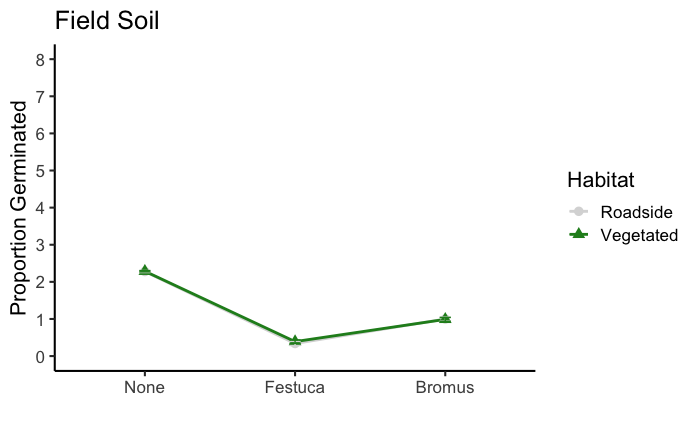

```r
pd<-position_dodge(0)

comp_int_bio_field<-log_mydata%>%
  filter(Soil=="Field Soil") %>%
  group_by(Competition,Habitat)%>%
  summarise(Mean=mean(log_Dittrichia),
            SD=sd(log_Dittrichia),
            N=length(log_Dittrichia))%>%
  mutate(SE=SD/sqrt(N))
comp_int_bio_field_gg<-ggplot(data=comp_int_bio_field,
                        aes(x=factor(Competition,levels=c("None","Festuca","Bromus")),
                            y=Mean,
                            shape=Habitat,
                            group=Habitat,
                            color=Habitat))+
  ylab("log(Biomass)")+
   scale_y_continuous(name="Proportion Germinated", #y-axis: title
                     limits=c(0,8), #x-axis: range
                     breaks=seq(0,8,1))+ #x-axis: incremental breaks by giving range and requesting a sequence by 1
  #coord_cartesian(ylim = c(1,8))+
  xlab("")+
  ggtitle("Field Soil")+
  theme_bw(base_size=16)+
  theme(panel.border=element_blank(),
        panel.grid.major=element_blank(),
        panel.grid.minor=element_blank(),
        axis.line=element_line(colour="black"))+
  geom_line(size=1,
            position=pd)+
  geom_point(size=3,
             position=pd)+
  scale_color_manual(values=c("gray85","forestgreen"))+
  geom_errorbar(width=0.15,
                position=pd,
                aes(ymin=(Mean-SE),
                    ymax=(Mean+SE)))
comp_int_bio_field_gg
```

```r
#ggsave(plot=comp_int_bio_field_gg,file="/Users/Miranda/Documents/Education/UC Santa Cruz/Dittrichia/Dittrichia_Analysis/figures/comp_int_bio_field_gg.png",width=25,height=20,units="cm",dpi=800)
```

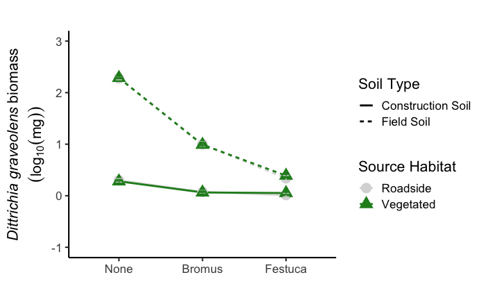

```r
pd<-position_dodge(0)

comp_int_bio_all<-log_mydata%>%
  group_by(Soil,Competition,Habitat)%>%
  summarise(Mean=mean(log_Dittrichia),
            SD=sd(log_Dittrichia),
            N=length(log_Dittrichia))%>%
  mutate(SE=SD/sqrt(N))
comp_int_bio_all_gg<-ggplot(data=comp_int_bio_all,
                        aes(x=factor(Competition,levels=c("None","Bromus","Festuca")),
                            y=Mean))+
  scale_y_continuous(expression(atop(italic("Dittrichia graveolens")~biomass, (log[10](mg)))),
                     limits=c(-1,3), #y-axis: range
                     breaks=seq(-1,3,1))+ #y-axis: incremental breaks by giving range and requesting a sequence by 1
  xlab("")+
  ggtitle("")+
  theme_classic(base_size=16)+
  # theme(panel.border=element_blank(),
  #       panel.grid.major=element_blank(),
  #       panel.grid.minor=element_blank(),
  #       axis.line=element_line(colour="black"))+
  geom_line(size=1,
            position=pd,
            aes(linetype=Soil,
                group=interaction(Soil,Habitat),
                color=Habitat))+
  geom_point(size=5,
             position=pd,
             aes(shape=Habitat,
                 color=Habitat))+
  scale_color_manual(values=c("gray85","forestgreen"))+
  geom_errorbar(width=0.15,
                position=pd,
                aes(ymin=(Mean-SE),
                    ymax=(Mean+SE),
                    color=Habitat))+
  labs(color="Source Habitat",
       shape="Source Habitat",
       linetype="Soil Type")
comp_int_bio_all_gg
```

```r
#ggsave(plot=comp_int_bio_all_gg,file="/Users/Miranda/Documents/Education/UC Santa Cruz/Dittrichia/Dittrichia_Analysis/figures/comp_int_bio_all_gg.png",width=25,height=15,units="cm",dpi=800)
```

[figure not shown]

Soil types together here too and using the log10 data on g

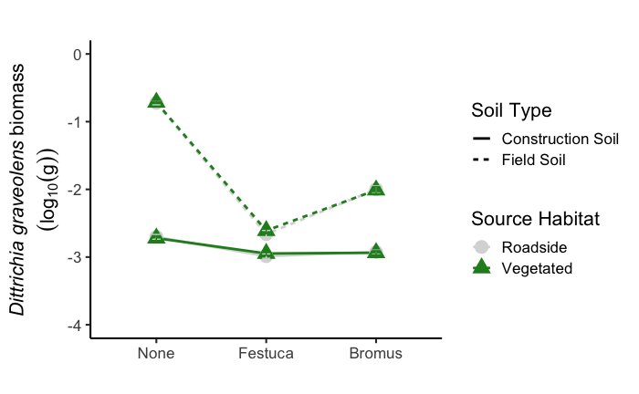

```r
pd<-position_dodge(0)

comp_int_bio_all<-log_mydata%>%
  group_by(Soil,Competition,Habitat)%>%
  summarise(Mean=mean(log_DittrichiaO),
            SD=sd(log_DittrichiaO),
            N=length(log_DittrichiaO))%>%
  mutate(SE=SD/sqrt(N))
comp_int_bio_all_gg<-ggplot(data=comp_int_bio_all,
                        aes(x=factor(Competition,levels=c("None","Festuca","Bromus")),
                            y=Mean))+
  scale_y_continuous(expression(atop(italic("Dittrichia graveolens")~biomass, (log[10](g)))),
                     limits=c(-4,0), #y-axis: range
                     breaks=seq(-4,0,1))+ #y-axis: incremental breaks by giving range and requesting a sequence by 1
  xlab("")+
  ggtitle("")+
  theme_classic(base_size=16)+
  # theme(panel.border=element_blank(),
  #       panel.grid.major=element_blank(),
  #       panel.grid.minor=element_blank(),
  #       axis.line=element_line(colour="black"))+
  geom_line(size=1,
            position=pd,
            aes(linetype=Soil,
                group=interaction(Soil,Habitat),
                color=Habitat))+
  geom_point(size=5,
             position=pd,
             aes(shape=Habitat,
                 color=Habitat))+
  scale_color_manual(values=c("gray85","forestgreen"))+
  geom_errorbar(width=0.15,
                position=pd,
                aes(ymin=(Mean-SE),
                    ymax=(Mean+SE),
                    color=Habitat))+
  labs(color="Source Habitat",
       shape="Source Habitat",
       linetype="Soil Type")
comp_int_bio_all_gg
```

```r
#ggsave(plot=comp_int_bio_all_gg,file="/Users/Miranda/Documents/Education/UC Santa Cruz/Dittrichia/Dittrichia_Analysis/figures/comp_int_bio_all_gg.png",width=25,height=15,units="cm",dpi=800)
```

#####Boxplot Not using

###Biomass x Competition and Soil and Population

#### Interaction Plots

Not used Plot by site.

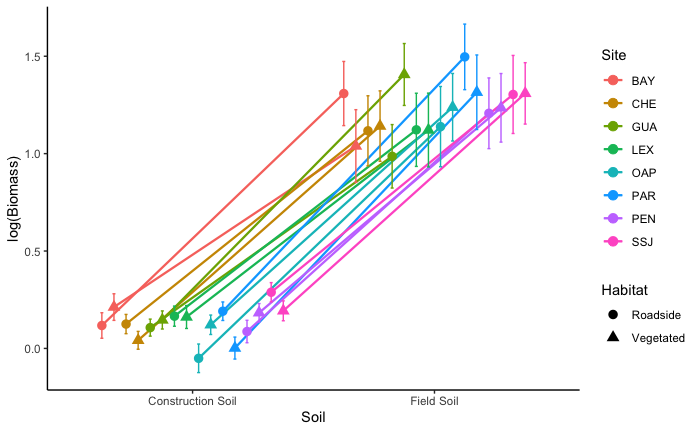

```r
mydata_site_sum<-log_mydata%>%
  group_by(Habitat,Soil,Site)%>%
  summarise(Mean=mean(log_Dittrichia),
            SD=sd(log_Dittrichia),
            N=length(log_Dittrichia))%>%
  mutate(SE=SD/sqrt(N))%>%
  mutate(Cat=paste(Site,Habitat,sep="_"))
pd<-position_dodge(.8)
comp_int_site_gg<-ggplot(data=mydata_site_sum,
                         aes(x=factor(Soil),
                             y=Mean,
                             color=Site,
                             shape=Habitat,
                             group=Cat))+
  ylab("log(Biomass)")+
  xlab("Soil")+
  theme_bw()+
  theme(panel.border=element_blank(),
        panel.grid.major=element_blank(),
        panel.grid.minor=element_blank(),
        axis.line=element_line(colour="black"))+
  geom_line(size=.8,position=pd)+
  geom_point(size=3,position=pd)+
  geom_errorbar(width=0.2,
                position=pd,
                aes(ymin=(Mean-SE),
                    ymax=(Mean+SE)))
comp_int_site_gg
```

Facet to make panels of the by site plot.

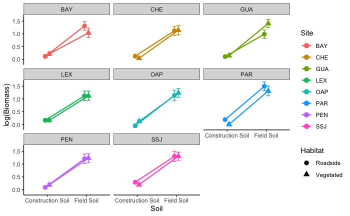

```r
mydata_site_sum<-log_mydata%>%
  group_by(Habitat,Soil,Site)%>%
  summarise(Mean=mean(log_Dittrichia),
            SD=sd(log_Dittrichia),
            N=length(log_Dittrichia))%>%
  mutate(SE=SD/sqrt(N))%>%
  mutate(Cat=paste(Site,Habitat,sep="_"))
pd<-position_dodge(.2)
comp_int_site_panel_gg<-ggplot(data=mydata_site_sum,
                               aes(x=factor(Soil),
                                   y=Mean,
                                   color=Site,
                                   shape=Habitat,
                                   group=Cat))+
  facet_wrap(~Site)+
  ylab("log(Biomass)")+
  xlab("Soil")+
  theme_bw()+
  theme(panel.border=element_blank(),
        panel.grid.major=element_blank(),
        panel.grid.minor=element_blank(),
        axis.line=element_line(colour="black"))+
  geom_line(size=.8,position=pd)+
  geom_point(size=3,position=pd)+
  geom_errorbar(width=0.2,position=pd,
                aes(ymin=(Mean-SE),
                    ymax=(Mean+SE)))
comp_int_site_panel_gg
```

####Boxplots Not using

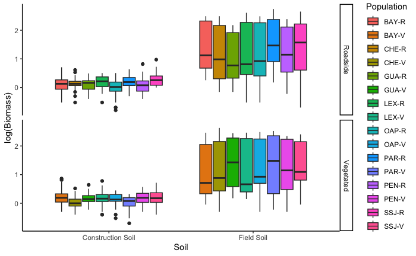

```r
competition2_gg<-ggplot(log_mydata)+
  geom_boxplot(aes(x=Soil,
                   y=log_Dittrichia,
                   fill=Population))+
  theme_classic()+
  facet_grid(Habitat~.)+
  labs(y="log(Biomass)",
       fill="Population",
       x="Soil")
competition2_gg
```

## Biomass Scatterplot

Using original data with negatives

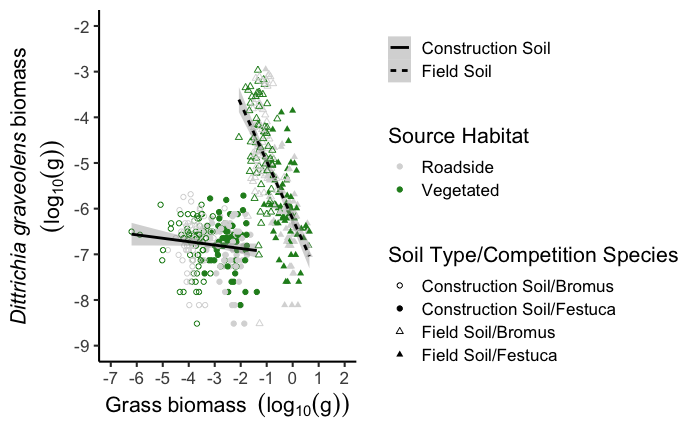

```r
#Prep data for scatterplot
comp_scatter<-log_mydata%>%
  filter(Competition!="None")%>%
  filter(Grass_biomass!=0)%>%
  mutate(scx=log(Grass_biomass),
         scy=log(Dittrichia_biomass))%>%
  mutate(type=paste(Soil,Competition,sep="/"))

#Make the scatterplot
comp_scatter_gg<-ggplot(comp_scatter)+
  geom_point(aes(
    x=scx,
    y=scy,
    shape=type,
    color=Habitat))+
  scale_y_continuous(expression(atop(italic("Dittrichia graveolens")~biomass, (log[10](g)))),
                     limits=c(-9,-2), #y-axis: range
                     breaks=seq(-9,-2,1))+ #y-axis: incremental breaks by giving range and requesting a sequence by 1
  scale_x_continuous(expression("Grass"~biomass ~""~(log[10](g))),
                     limits=c(-7,2), #x-axis: range
                     breaks=seq(-7,2,1))+ #x-axis: incremental breaks by giving range and requesting a sequence by 1
  guides(fill=none)+
  scale_color_manual(values=c("gray85","forestgreen"))+
  scale_shape_manual(values=c(1,19,2,17))+
  geom_smooth(method=lm,
              aes(x=scx,
                  y=scy,
                  linetype=Soil),
              color="black")+
  theme_classic(base_size=16)+
  theme(panel.border=element_blank(),
        panel.grid.major=element_blank(),
        panel.grid.minor=element_blank(),
        axis.line=element_line(colour="black"))+
  labs(y="Dittrichia graveolens biomass (log(g10^4))",
       x="Grass biomass (log(g10^4))",
       shape="Soil Type/Competition Species",
       color="Source Habitat",
       linetype="")
comp_scatter_gg
```

```r
#ggsave(plot=comp_scatter_gg,file ="/Users/Miranda/Documents/Education/UC Santa Cruz/Dittrichia/Dittrichia_Analysis/figures/comp_scatter_gg.png",width=25,height=15,units="cm",dpi=800)
```

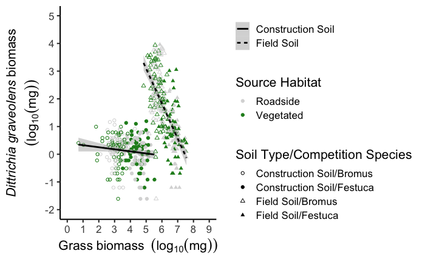

```r
#Prep data for scatterplot
comp_scatter<-log_mydata%>%
  filter(Competition!="None")%>%
  filter(Grass_biomass!=0)%>%
  mutate(scx=log(Grass_biomass1000),
         scy=log(Dittrichia_biomass1000))%>%
  mutate(type=paste(Soil,Competition,sep="/"))

#Make the scatterplot
comp_scatter_gg<-ggplot(comp_scatter)+
  geom_point(aes(
    x=scx,
    y=scy,
    shape=type,
    color=Habitat))+
  scale_y_continuous(expression(atop(italic("Dittrichia graveolens")~biomass, (log[10](mg)))),
                     limits=c(-2,5), #y-axis: range
                     breaks=seq(-2,5,1))+ #y-axis: incremental breaks by giving range and requesting a sequence by 1
  scale_x_continuous(expression("Grass"~biomass ~""~(log[10](mg))),
                     limits=c(0,9), #x-axis: range
                     breaks=seq(0,9,1))+ #x-axis: incremental breaks by giving range and requesting a sequence by 1
  guides(fill=none)+
  scale_color_manual(values=c("gray85","forestgreen"))+
  scale_shape_manual(values=c(1,19,2,17))+
  geom_smooth(method=lm,
              aes(x=scx,
                  y=scy,
                  linetype=Soil),
              color="black")+
  theme_classic(base_size=16)+
  theme(panel.border=element_blank(),
        panel.grid.major=element_blank(),
        panel.grid.minor=element_blank(),
        axis.line=element_line(colour="black"))+
  labs(y="Dittrichia graveolens biomass (log(g10^4))",
       x="Grass biomass (log(g10^4))",
       shape="Soil Type/Competition Species",
       color="Source Habitat",
       linetype="")
comp_scatter_gg
```

```r
#ggsave(plot=comp_scatter_gg,file ="/Users/Miranda/Documents/Education/UC Santa Cruz/Dittrichia/Dittrichia_Analysis/figures/comp_scatter_gg.png",width=25,height=15,units="cm",dpi=800)
```

#Dittrichia Growth

Here we need to filter the data to only look at plant growth > 0

```r
mydata_Dgrowth<-mydata%>%filter(DittrichiaLLL_mm_3>0) #Here I am only looking at the Dittrichia growth data that is greater than 0
#mydata_Ggrowth<-mydata%>%filter(GrassHeight_cm_3>0) #Here I am only looking at the Dittrichia growth data that is greater than 0
```

##Histograms

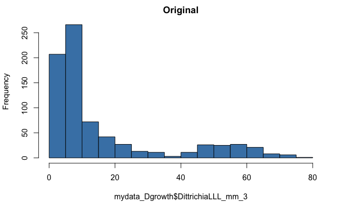

```r
#Dittrichia longest leaf length
hist(mydata_Dgrowth$DittrichiaLLL_mm_3,col='steelblue',main='Original')
```

Data is skewed, so let’s try log transforming.

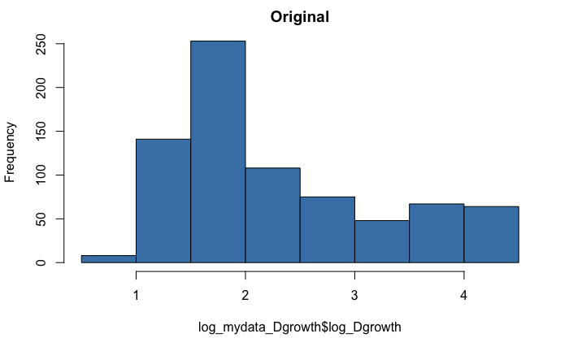

```r
#Prepare data for log transform
log_mydata_Dgrowth<-mydata_Dgrowth%>%
  filter(Dittrichia_biomass!=0)%>%
 mutate(log_Dgrowth=log(DittrichiaLLL_mm_3))

hist(log_mydata_Dgrowth$log_Dgrowth,col='steelblue',main='Original')
```

```r
shapiro.test(log_mydata_Dgrowth$log_Dgrowth) #does not improve with log transform
```

```
    Shapiro-Wilk normality test

data:  log_mydata_Dgrowth$log_Dgrowth
W = 0.88714, p-value < 2.2e-16
```

##Model ###Best Model ###Risk Assessment ##ggplot ###Growth Rate x Competition and Soil

All data combined.

#####Growth Rate vs. Competition: Construction soil

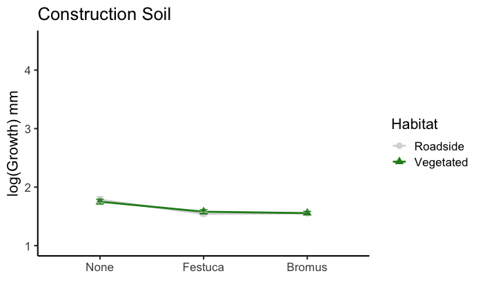

```r
pd<-position_dodge(0)

comp_int_grow_con<-log_mydata_Dgrowth%>%
  filter(Soil=="Construction Soil")%>%
  group_by(Competition,Habitat)%>%
  summarise(Mean=mean(log_Dgrowth),
            SD=sd(log_Dgrowth),
            N=length(log_Dgrowth))%>%
  mutate(SE=SD/sqrt(N))
comp_int_grow_con_gg<-ggplot(data=comp_int_grow_con,
                        aes(x=factor(Competition,levels=c("None","Festuca","Bromus")),
                            y=Mean,
                            shape=Habitat,
                            group=Habitat,
                            color=Habitat))+
  ylab("log(Growth) mm")+
  coord_cartesian(ylim = c(1,4.5))+
  xlab("")+
  ggtitle("Construction Soil")+
  theme_bw(base_size=16)+
  theme(panel.border=element_blank(),
        panel.grid.major=element_blank(),
        panel.grid.minor=element_blank(),
        axis.line=element_line(colour="black"))+
  geom_line(size=1,
            position=pd)+
  geom_point(size=3,
             position=pd)+
  scale_color_manual(values=c("gray85","forestgreen"))+
  geom_errorbar(width=0.15,
                position=pd,
                aes(ymin=(Mean-SE),
                    ymax=(Mean+SE)))
comp_int_grow_con_gg
```

```r
#ggsave(plot=comp_int_grow_con_gg,file="/Users/Miranda/Documents/Education/UC Santa Cruz/Dittrichia/Dittrichia_Analysis/figures/comp_int_grow_con_gg.png",width=25,height=20,units="cm",dpi=800)
```

#####Growth Rate vs. Competition: Field soil

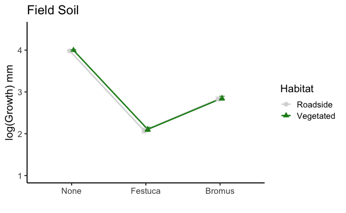

```r
pd<-position_dodge(0.1)

comp_int_grow_field<-log_mydata_Dgrowth%>%
  filter(Soil=="Field Soil") %>%
  group_by(Competition,Habitat)%>%
  summarise(Mean=mean(log_Dgrowth),
            SD=sd(log_Dgrowth),
            N=length(log_Dgrowth))%>%
  mutate(SE=SD/sqrt(N))
comp_int_grow_field_gg<-ggplot(data=comp_int_grow_field,
                        aes(x=factor(Competition,levels=c("None","Festuca","Bromus")),
                            y=Mean,
                            shape=Habitat,
                            group=Habitat,
                            color=Habitat))+
  ylab("log(Growth) mm")+
  coord_cartesian(ylim=c(1,4.5))+
  xlab("")+
  ggtitle("Field Soil")+
  theme_bw(base_size=16)+
  theme(panel.border=element_blank(),
        panel.grid.major=element_blank(),
        panel.grid.minor=element_blank(),
        axis.line=element_line(colour="black"))+
  geom_line(size=1,
            position=pd)+
  geom_point(size=3,
             position=pd)+
  scale_color_manual(values=c("gray85","forestgreen"))+
  geom_errorbar(width=0.15,
                position=pd,
                aes(ymin=(Mean-SE),
                    ymax=(Mean+SE)))
comp_int_grow_field_gg
```

```r
#ggsave(plot=comp_int_grow_field_gg,file="/Users/Miranda/Documents/Education/UC Santa Cruz/Dittrichia/Dittrichia_Analysis/figures/comp_int_grow_field_gg.png",width=25,height=20,units="cm",dpi=800)
```

#Load field soil data only

```r
str(mydata_field1) #Check that each column has the right class (factor, integer, numeric, etc.)
```

```
'data.frame':   384 obs. of  19 variables:
 $ Pot.ID            : int  649 521 393 641 513 385 665 537 409 657 ...
 $ Soil              : Factor w/ 1 level "Field Soil": 1 1 1 1 1 1 1 1 1 1 ...
 $ Site              : Factor w/ 8 levels "BAY","CHE","GUA",..: 1 1 1 1 1 1 2 2 2 2 ...
 $ Block             : int  1 1 1 1 1 1 1 1 1 1 ...
 $ Habitat           : Factor w/ 2 levels "Roadside","Vegetated": 1 1 1 2 2 2 1 1 1 2 ...
 $ Competition       : Factor w/ 3 levels "Bromus","Festuca",..: 1 2 3 1 2 3 1 2 3 1 ...
 $ Population        : Factor w/ 16 levels "BAY-R","BAY-V",..: 1 1 1 2 2 2 3 3 3 4 ...
 $ Biomass_date      : Factor w/ 8 levels "12/10/22","12/11/22",..: 7 7 7 6 7 6 6 7 7 6 ...
 $ Dittrichia_biomass: num  0.0221 0.0068 0.2456 0.0088 0.0024 ...
 $ LRR_All           : num  43 122 1 97 190 1 27 203 1 109 ...
 $ Grass_biomass     : num  0.215 0.414 0 0.272 0.631 ...
 $ MeasurementDate_2 : Factor w/ 3 levels "9/14/21","9/15/21",..: 1 2 1 2 1 2 2 1 1 2 ...
 $ MeasurementDate_3 : Factor w/ 3 levels "10/15/21","10/16/21",..: 1 1 1 1 1 1 1 1 1 1 ...
 $ GrassHeight_cm_2  : num  29.3 53.6 NA 29.8 55 NA 27.7 44.9 NA 29.5 ...
 $ GrassHeight_cm_3  : num  29.1 71.8 0 31.5 65.1 0 27.6 43.5 0 32.1 ...
 $ GrassGrowth       : num  -0.2 18.2 0 1.7 10.1 0 -0.1 -1.4 0 2.6 ...
 $ DittrichiaLLL_mm_2: num  15.63 7.39 50.59 8.41 7.75 ...
 $ DittrichiaLLL_mm_3: num  23.45 9.48 59.48 13.92 9.71 ...
 $ DittrichiaGrowth  : num  7.82 2.09 8.89 5.51 1.96 ...
```

##Summarize data